# Within-season mass trajectory for breeding individuals

issue #5 task 4

2026-09-24

# 1 Background

Issue #5 task 4: for birds identified as breeding (task 2), how does mass change over the course of the breeding season (early vs. late - the cost of incubation/chick-rearing), and has that within-season trajectory shifted in recent years?

Scoped per Inbal (2026-09-08):

- **Little Tern**: task 3 found no significant mass-vs-year trend for this species in any group (juvenile/breeder/non-breeder/unsplit) - so no need to split the within-season analysis by year here. Just check whether there’s a within-season pattern at all (pooled across all years).
- **Common Tern**: check the within-season pattern *and* whether it differs by year - motivated by a field observation this year (terns seen bringing fish they couldn’t eat, not observed in previous years) - a possible food-availability signal that might show up as an unusual within-season mass trajectory in the most recent year specifically.

# 2 Data loading

```r
raw_dir <- "../../data_raw"
if (!dir.exists(raw_dir)) raw_dir <- "../data_raw"
if (!dir.exists(raw_dir)) raw_dir <- "data_raw"
stopifnot(dir.exists(raw_dir))

proc_dir <- "../../data_processed"
if (!dir.exists(proc_dir)) proc_dir <- "../data_processed"
if (!dir.exists(proc_dir)) proc_dir <- "data_processed"

ringing_path <- file.path(raw_dir, "ringing_data_raw.xlsx")
stopifnot(file.exists(ringing_path))

col_names_47 <- c(
  "CR1","RingReplace","Rec","RingPrefix","RingNum","Species","Sex","Age","Wing","Weight",
  "Date","Time","Place","Lat","Lon","Ringer","Country","Remarks","Net","CR2","Subsp","Tail","Head",
  "Breeding","CP1","CP2","CP3","CP4","Colour","D","M","OrigDate","OrigCountry","OrigLat","OrigLon","OrigAge",
  "OldCR1","OldCR2","OldCR3","OldMetal1","OldMetal2","OilHead","OilWings","OilUpperP","OilUnderP","OilLegs","OilSum"
)
raw <- read_excel(ringing_path, sheet = "Data", skip = 2, col_names = col_names_47)

terns <- raw %>%
  filter(Species %in% c("STEALB", "STEHIR")) %>%
  mutate(
    year = year(Date),
    month = month(Date),
    ring_id = paste0(trimws(RingPrefix), RingNum),
    is_new = is.na(Rec) | trimws(Rec) == "",
    species_label = ifelse(Species == "STEHIR", "Common Tern", "Little Tern")
  )
```

# 3 Identifying breeding individuals and their within-season records

Reuses the task 2c confirmed-breeder definition: any adult (new ringing or recapture) weighed in spring (Mar-May), confirmed as a breeder if that ring was also recorded in June/July of any year.

```r
juvenile_ages <- c(1, 3)

summer_ring_ids_anyyear <- terns %>%
  filter(month %in% 6:7) %>%
  distinct(ring_id) %>%
  pull(ring_id)

confirmed_breeder_ids <- terns %>%
  filter(!(Age %in% juvenile_ages), !is.na(Weight), month %in% 3:5) %>%
  filter(ring_id %in% summer_ring_ids_anyyear) %>%
  distinct(ring_id, Species)

kable(confirmed_breeder_ids %>% count(Species), caption = "Confirmed-breeder individuals (distinct ring_id)")
```

Confirmed-breeder individuals (distinct ring_id)

| Species | n |
| --- | --- |
| STEALB | 171 |
| STEHIR | 473 |

**Season window**: Jun-Aug (broader than task 2’s Jun-Jul, to cover the full incubation-through-fledging period so “early vs. late season” has something to contrast - trimmed at Aug since Sep records are negligible sheet-wide, see `data_raw/README.md`). All weighed records (new ringing OR recapture) for a confirmed breeder’s ring in this window, any year, count as one within-season data point - not restricted to `is_new` here, since we want every weighing of a known breeder across the season, not just first captures.

```r
breeding_season_records <- terns %>%
  filter(!is.na(Weight), month %in% 6:8) %>%
  inner_join(confirmed_breeder_ids, by = c("ring_id", "Species")) %>%
  # Date comes in as POSIXct from readxl (not plain Date), so a naive
  # Date - Date subtraction returns a difftime in SECONDS, not days - force
  # both sides to Date class first so the subtraction is genuinely in days.
  mutate(day_of_season = as.numeric(as.Date(Date) - as.Date(ymd(paste0(year, "-06-01")))))

kable(breeding_season_records %>% count(species_label, name = "n_records"),
      caption = "Within-season (Jun-Aug) weighed records for confirmed breeders")
```

Within-season (Jun-Aug) weighed records for confirmed breeders

| species_label | n_records |
| --- | --- |
| Common Tern | 75 |
| Little Tern | 72 |

**Important data-availability caveat**: a confirmed breeder is identified from *any* record (recapture or resighting, weighed or not) in June/July of any year, but this task needs an actual *weighed* Jun-Aug record to put on the mass-vs-day-of-season axis - and those are much rarer, since most summer contact with already-ringed adults is a resighting (colour ring read at a distance), not a physical recapture. In practice this means the most recent **weighed** within-season record for a confirmed Common Tern breeder is from **2023** - there are none in 2024, 2025, or 2026. Little Tern is similarly thin in recent years (a single record in 2025, none in 2021/2023/2024/2026). **This means the “most recent year” analysis below cannot actually test 2026 against prior years - there is no weighed data to test it with** - so it does not directly speak to this year’s field observation (terns bringing fish they couldn’t eat). Flagging this plainly rather than letting the 2023-vs-prior result read as if it addresses the 2026 observation.

# 4 Little Tern: within-season pattern (pooled across years)

```r
alb_season <- breeding_season_records %>% filter(Species == "STEALB")

m_alb <- lm(Weight ~ day_of_season, data = alb_season)
s_alb <- summary(m_alb)

cat("Little Tern: slope =", round(coef(m_alb)["day_of_season"], 4), "g/day, p =",
    signif(s_alb$coefficients["day_of_season", "Pr(>|t|)"], 3),
    ", n =", nrow(alb_season), "\n")
```

```
## Little Tern: slope = -0.0103 g/day, p = 0.686 , n = 72
```

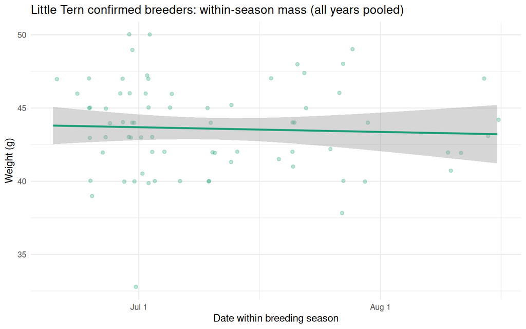

```r
ggplot(alb_season, aes(day_of_season, Weight)) +
  geom_jitter(width = 0.5, alpha = 0.3, color = "#1b9e77") +
  geom_smooth(method = "lm", color = "#1b9e77") +
  scale_x_continuous(breaks = c(0, 30, 61, 91), labels = c("Jun 1", "Jul 1", "Aug 1", "Aug 31")) +
  labs(title = "Little Tern confirmed breeders: within-season mass (all years pooled)",
       x = "Date within breeding season", y = "Weight (g)") +
  theme_minimal()
```

## 4.1 Interpretation

No year-splitting here per the scoping above - task 3 already established there’s no significant Little Tern mass-vs-year trend to interact with a within-season pattern.

# 5 Common Tern: within-season pattern, and does it differ by year?

```r
hir_season <- breeding_season_records %>% filter(Species == "STEHIR")

m_hir <- lm(Weight ~ day_of_season, data = hir_season)
s_hir <- summary(m_hir)

cat("Common Tern (pooled): slope =", round(coef(m_hir)["day_of_season"], 4), "g/day, p =",
    signif(s_hir$coefficients["day_of_season", "Pr(>|t|)"], 3),
    ", n =", nrow(hir_season), "\n")
```

```
## Common Tern (pooled): slope = 0.1444 g/day, p = 0.00754 , n = 75
```

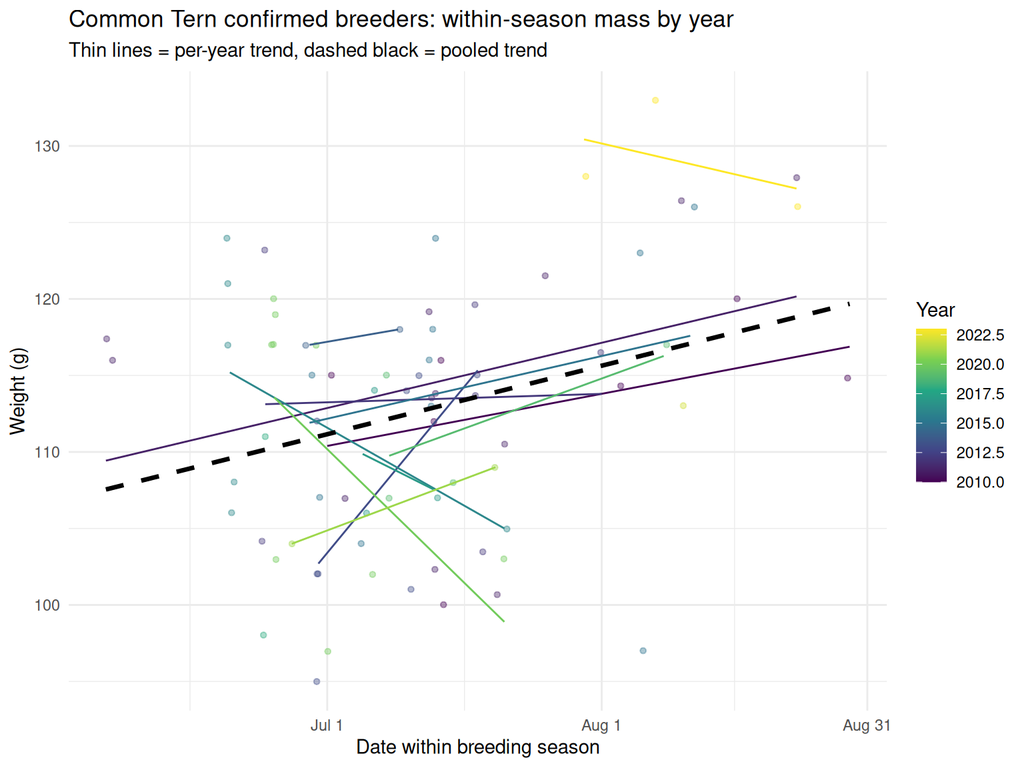

```r
ggplot(hir_season, aes(day_of_season, Weight, color = year)) +
  geom_jitter(width = 0.5, alpha = 0.4, size = 1.2) +
  geom_smooth(aes(group = year), method = "lm", se = FALSE, linewidth = 0.5, alpha = 0.6) +
  geom_smooth(color = "black", method = "lm", se = FALSE, linewidth = 1.2, linetype = "dashed") +
  scale_color_viridis_c(name = "Year") +
  scale_x_continuous(breaks = c(0, 30, 61, 91), labels = c("Jun 1", "Jul 1", "Aug 1", "Aug 31")) +
  labs(title = "Common Tern confirmed breeders: within-season mass by year",
       subtitle = "Thin lines = per-year trend, dashed black = pooled trend",
       x = "Date within breeding season", y = "Weight (g)") +
  theme_minimal()
```

## 5.1 Does the within-season trajectory differ by year?

```r
m_interact <- lm(Weight ~ day_of_season * factor(year), data = hir_season)
a_interact <- anova(m_interact)
p_interact <- signif(a_interact["day_of_season:factor(year)", "Pr(>F)"], 3)
cat("day_of_season x year interaction: p =", p_interact, "\n")
```

```
## day_of_season x year interaction: p = 0.616
```

## 5.2 Is the most recent year (with weighed data) different from prior years?

**Not a test of 2026** - see the data-availability caveat above. This tests whether 2023 (the most recent year that has any weighed within-season records for a confirmed breeder) differs from the pooled trajectory of prior years. Included for completeness/robustness of the interaction test above, not as an answer to the field observation - that would need either a weighed sample from 2026 that doesn’t currently exist, or a different proxy (e.g. resighted body condition scores, if those exist) to substitute for actual mass.

```r
hir_season_recent <- hir_season %>%
  mutate(is_recent_year = year == max(year))

m_recent <- lm(Weight ~ day_of_season * is_recent_year, data = hir_season_recent)
s_recent <- summary(m_recent)
kable(as.data.frame(round(s_recent$coefficients, 4)),
      caption = paste("Weight ~ day_of_season * is_recent_year (", max(hir_season$year), "vs. all prior years)"))
```

Weight ~ day_of_season * is_recent_year ( 2023 vs. all prior years)

|  | Estimate | Std. Error | t value | Pr(>\|t\|) |
| --- | --- | --- | --- | --- |
| (Intercept) | 108.2256 | 2.3166 | 46.7180 | 0.0000 |
| day_of_season | 0.0965 | 0.0536 | 1.7996 | 0.0762 |
| is_recent_yearTRUE | 30.1047 | 31.7016 | 0.9496 | 0.3455 |
| day_of_season:is_recent_yearTRUE | -0.2304 | 0.4524 | -0.5093 | 0.6121 |

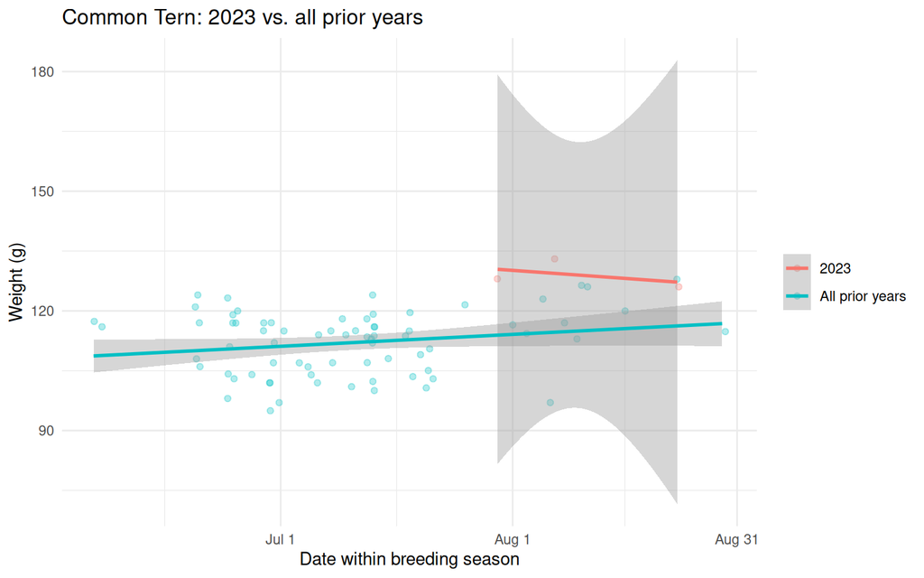

```r
hir_season_recent %>%
  mutate(year_group = ifelse(is_recent_year, as.character(max(hir_season$year)), "All prior years")) %>%
  ggplot(aes(day_of_season, Weight, color = year_group)) +
  geom_jitter(width = 0.5, alpha = 0.3) +
  geom_smooth(method = "lm", se = TRUE) +
  scale_x_continuous(breaks = c(0, 30, 61, 91), labels = c("Jun 1", "Jul 1", "Aug 1", "Aug 31")) +
  labs(title = paste("Common Tern:", max(hir_season$year), "vs. all prior years"),
       x = "Date within breeding season", y = "Weight (g)", color = NULL) +
  theme_minimal()
```

# 6 Save outputs

```r
write.csv(breeding_season_records %>% select(-species_label),
          file.path(proc_dir, "within_season_mass_records.csv"), row.names = FALSE)
cat("Wrote data_processed/within_season_mass_records.csv\n")
```

```
## Wrote data_processed/within_season_mass_records.csv
```